# SAS: Part 0 - Base SAS, PROC SGPLOT

## License

Copyright (c) 2015 by SAS Institute Inc., Cary, NC 27513 USA

Licensed under the Apache License, Version 2.0 (the "License"); you may not use this file except in compliance with the License. You may obtain a copy of the License at

http://www.apache.org/licenses/LICENSE-2.0

Unless required by applicable law or agreed to in writing, software distributed under the License is distributed on an "AS IS" BASIS, WITHOUT WARRANTIES OR CONDITIONS OF ANY KIND, either express or implied. See the License for the specific language governing permissions and limitations under the License.

#### NOTE: these examples are meant for the free SAS University Edition

- To install see: http://www.sas.com/en_us/software/university-edition.html
- SAS University Edition includes SAS kernel for Jupyter

## 1. SAS Output

- The `_null_ data` step allows you to execute commands (like writing to the log) or to read a data set without creating a new data set
- The `put` command outputs information to the log

```sas
data _null_;
    put 'Hello world!'; /* put command to the log */
run;
```

```
11   ods listing close;ods html5 file=stdout options(bitmap_mode='inline') device=png; ods graphics on / outputfmt=png;
NOTE: Writing HTML5 Body file: STDOUT
12
13   data _null_;
14       put 'Hello world!'; /* put command to the log */
15   run;
Hello world!
NOTE: DATA statement used (Total process time):
      real time           0.00 seconds
      cpu time            0.00 seconds

16   ods html5 close;ods listing;

17
```

##### Print the value of a variable to the log

```sas
data _null_;
    x = 'Hello world!';
    put x;
    put x=; /* useful for debugging */
run;
```

```
19   ods listing close;ods html5 file=stdout options(bitmap_mode='inline') device=png; ods graphics on / outputfmt=png;
NOTE: Writing HTML5 Body file: STDOUT
20
21   data _null_;
22       x = 'Hello world!';
23       put x;
24       put x=; /* useful for debugging */
25   run;
Hello world!
x=Hello world!
NOTE: DATA statement used (Total process time):
      real time           0.00 seconds
      cpu time            0.00 seconds

26   ods html5 close;ods listing;

27
```

##### `file print` redirects the results to html in a Jupyter notebook

```sas
data _null_;
    file print; /* redirects the results to html*/
    put 'Hello world!';
run;
```

The SAS System

```
Hello world!
```

##### Logging information levels - use these prefixes to print color-coded information to the log

```sas
data _null_;
    put 'NOTE: Hello world!';
    put 'WARNING: Hello world!';
    put 'ERROR: Hello world!';
run;
```

```
38   ods listing close;ods html5 file=stdout options(bitmap_mode='inline') device=png; ods graphics on / outputfmt=png;
NOTE: Writing HTML5 Body file: STDOUT
39
40   data _null_;
41       put 'NOTE: Hello world!';
42       put 'WARNING: Hello world!';
43       put 'ERROR: Hello world!';
44   run;
NOTE: Hello world!
WARNING: Hello world!
ERROR: Hello world!
NOTE: DATA statement used (Total process time):
      real time           0.00 seconds
      cpu time            0.00 seconds

45   ods html5 close;ods listing;

46
```

##### You can also use the put macro statement

- SAS macro statements are often used for program flow control around `data` step statements and SAS procedures
- This tutorial will only use simple macro statements

```sas
%put Hello world!;
%put NOTE: Hello world!;
%put WARNING: Hello world!;
%put ERROR: Hello world!;
```

```
48   ods listing close;ods html5 file=stdout options(bitmap_mode='inline') device=png; ods graphics on / outputfmt=png;
NOTE: Writing HTML5 Body file: STDOUT
49
50   %put Hello world!;
Hello world!
51   %put NOTE: Hello world!;
NOTE: Hello world!
52   %put WARNING: Hello world!;
WARNING: Hello world!
53   %put ERROR: Hello world!;
ERROR: Hello world!
54   ods html5 close;ods listing;

55
```

##### Macro variables are ALWAYS strings

```sas
%put 'Hello world!'; /* single quotes will be printed */
```

```
57   ods listing close;ods html5 file=stdout options(bitmap_mode='inline') device=png; ods graphics on / outputfmt=png;
NOTE: Writing HTML5 Body file: STDOUT
58
59   %put 'Hello world!'; /* single quotes will be printed */
'Hello world!'
60   ods html5 close;ods listing;

61
```

##### The macro preprocessor resolves macro variables as text literals before `data` step code is executed

- Single quotes PREVENT macro resolution
- Double quotes ALLOW macro resolution

```sas
%let x = Hello world!;
%put &x;
%put '&x'; /* single quotes PREVENT macro resolution */
%put "&x"; /* double quotes ALLOW macro resolution */
```

```
63   ods listing close;ods html5 file=stdout options(bitmap_mode='inline') device=png; ods graphics on / outputfmt=png;
NOTE: Writing HTML5 Body file: STDOUT
64
65   %let x = Hello world!;
66   %put &x;
Hello world!
67   %put '&x'; /* single quotes PREVENT macro resolution */
'&x'
68   %put "&x"; /* double quotes ALLOW macro resolution */
"Hello world!"
69   ods html5 close;ods listing;

70
```

## 2. Generate a sample data set

The SAS data set is the primary data structure in the SAS language

- To simulate a sample data set for this example, macro variables are used to define the number of columns and rows
- The size of data set is more typically defined by the size of the SAS data set(s) from which it is created

```sas
%let n_rows = 1000; /* define number of rows */
%let n_vars = 2;    /* define number of character and numeric variables */
```

```
72   ods listing close;ods html5 file=stdout options(bitmap_mode='inline') device=png; ods graphics on / outputfmt=png;
NOTE: Writing HTML5 Body file: STDOUT
73
74   %let n_rows = 1000; /* define number of rows */
75   %let n_vars = 2;    /* define number of character and numeric variables */
76   ods html5 close;ods listing;

77
```

##### The SAS `data` step is used to create and manipulate data sets

```sas
* options mprint; /* to see the macro variables resolve uncomment this line */
data scratch;

    /* data sets can be made permanent by creating them in a library */
    /* syntax: data <library>.<table> */
    /* a library is like a database */
    /* a library is usually directly mapped to a filesystem directory */
    /* since a permanent library was not specified for the data set */
    /* the scratch data set will be created in the temporary library, work */
    /* it will be deleted when you leave SAS */

    /* SAS is strongly typed - it is safest to declare variables */
    /* using a length statement - especially for character variables */
    /* $ denotes a character variable */

    /* arrays are a data structure that can exist during the data step */
    /* they are a reference to a group of variables */
    /* horizontally across a data set */
    /* $ denotes a character array */
    /* do loops are often used in conjuction with arrays */
    /* SAS arrays are indexed from 1, like R data structures */

    /* a key is a variable with a unique value for each row */

    /* mod() is the modulo function */
    /* the %eval() macro function performs math operations */
    /* before text substitution */

    /* the drop statement removes variables from the output data set */

    /* since you are not reading from a pre-existing data set */
    /* you must output rows explicitly using the output statement */

    length key 8 char1-char&n_vars $ 8 numeric1-numeric&n_vars 8;
    text_draw = 'AAAAAAAA BBBBBBBB CCCCCCCC DDDDDDDD EEEEEEEE FFFFFFFF GGGGGGGG';
    array c $ char1-char&n_vars;
    array n numeric1-numeric&n_vars;
    do i=1 to &n_rows;
        key = i;
        do j=1 to %eval(&n_vars);
            /* assign a random value from text_draw */
            /* to each element of the array c */
            c[j] = scan(text_draw, floor(7*ranuni(12345)+1), ' ');
            /* assign a random numeric value to each element of the n array */
            /* ranuni() requires a seed value */
            n[j] = ranuni(%eval(&n_rows*&n_vars));
        end;
      if mod(i, %eval(&n_rows/10)) = 0 then put 'Processing line ' i '...';
        drop i j text_draw;
        output;
    end;
    put 'Done.';
run;
```

```
79   ods listing close;ods html5 file=stdout options(bitmap_mode='inline') device=png; ods graphics on / outputfmt=png;
NOTE: Writing HTML5 Body file: STDOUT
80
81   * options mprint; /* to see the macro variables resolve uncomment this line */
82   data scratch;
83
84       /* data sets can be made permanent by creating them in a library */
85       /* syntax: data <library>.<table> */
86       /* a library is like a database */
87       /* a library is usually directly mapped to a filesystem directory */
88       /* since a permanent library was not specified for the data set */
89       /* the scratch data set will be created in the temporary library, work */
90       /* it will be deleted when you leave SAS */
91
92       /* SAS is strongly typed - it is safest to declare variables */
93       /* using a length statement - especially for character variables */
94       /* $ denotes a character variable */
95
96       /* arrays are a data structure that can exist during the data step */
97       /* they are a reference to a group of variables */
98       /* horizontally across a data set */
99       /* $ denotes a character array */
100      /* do loops are often used in conjuction with arrays */
101      /* SAS arrays are indexed from 1, like R data structures */
102
103      /* a key is a variable with a unique value for each row */
104
105      /* mod() is the modulo function */
106      /* the %eval() macro function performs math operations */
107      /* before text substitution */
108
109      /* the drop statement removes variables from the output data set */
110
111      /* since you are not reading from a pre-existing data set */
112      /* you must output rows explicitly using the output statement */
113
114      length key 8 char1-char&n_vars $ 8 numeric1-numeric&n_vars 8;
115      text_draw = 'AAAAAAAA BBBBBBBB CCCCCCCC DDDDDDDD EEEEEEEE FFFFFFFF GGGGGGGG';
116      array c $
116! char1-char&n_vars;
```

[output cut: 22 more lines]

```
Processing line 500 ...
Processing line 600 ...
Processing line 700 ...
Processing line 800 ...
Processing line 900 ...
Processing line 1000 ...
Done.
NOTE: The data set WORK.SCRATCH has 1000 observations and 5 variables.
NOTE: DATA statement used (Total process time):
      real time           0.00 seconds
      cpu time            0.00 seconds

134  ods html5 close;ods listing;

135
```

##### Use `PROC PRINT` to print the data set

Procedure output is directed to html automatically in a Jupyter notebook

```sas
/* (obs=) option enables setting the number of rows to print */
proc print data=scratch (obs=5); run;
```

The SAS System

| Obs | key | char1 | char2 | numeric1 | numeric2 |
| --- | --- | --- | --- | --- | --- |
| 1 | 1 | CCCCCCCC | FFFFFFFF | 0.74519 | 0.27628 |
| 2 | 2 | BBBBBBBB | AAAAAAAA | 0.72888 | 0.73432 |
| 3 | 3 | EEEEEEEE | DDDDDDDD | 0.76408 | 0.18159 |
| 4 | 4 | BBBBBBBB | DDDDDDDD | 0.39360 | 0.85949 |
| 5 | 5 | CCCCCCCC | BBBBBBBB | 0.18129 | 0.23532 |

## 3. Basic data manipulation and analysis

##### Use `proc contents` to understand basic information about a data set

```sas
proc contents data=scratch; run;
```

The SAS System

The CONTENTS Procedure

| Data Set Name | WORK.SCRATCH | Observations | 1000 |
| --- | --- | --- | --- |
| Member Type | DATA | Variables | 5 |
| Engine | V9 | Indexes | 0 |
| Created | 11/22/2016 19:35:19 | Observation Length | 40 |
| Last Modified | 11/22/2016 19:35:19 | Deleted Observations | 0 |
| Protection |  | Compressed | NO |
| Data Set Type |  | Sorted | NO |
| Label |  |  |  |
| Data Representation | SOLARIS_X86_64, LINUX_X86_64, ALPHA_TRU64, LINUX_IA64 |  |  |
| Encoding | utf-8 Unicode (UTF-8) |  |  |

| Engine/Host Dependent Information |  |
| --- | --- |
| Data Set Page Size | 65536 |
| Number of Data Set Pages | 1 |
| First Data Page | 1 |
| Max Obs per Page | 1632 |
| Obs in First Data Page | 1000 |
| Number of Data Set Repairs | 0 |
| Filename | /tmp/SAS_work286200003E73_localhost.localdomain/scratch.sas7bdat |
| Release Created | 9.0401M3 |
| Host Created | Linux |
| Inode Number | 277710 |
| Access Permission | rw-r--r-- |
| Owner Name | sasdemo |
| File Size | 128KB |
| File Size (bytes) | 131072 |

| Alphabetic List of Variables and Attributes # | Alphabetic List of Variables and Attributes Variable | Alphabetic List of Variables and Attributes Type | Alphabetic List of Variables and Attributes Len |
| --- | --- | --- | --- |
| 2 | char1 | Char | 8 |
| 3 | char2 | Char | 8 |
| 1 | key | Num | 8 |
| 4 | numeric1 | Num | 8 |
| 5 | numeric2 | Num | 8 |

##### Use `PROC FREQ` to analyze categorical data

The SAS System

The FREQ Procedure

| Number of Variable Levels Variable | Number of Variable Levels Levels |
| --- | --- |
| char1 | 7 |
| char2 | 7 |

| char1 | Frequency | Percent | Cumulative Frequency | Cumulative Percent |
| --- | --- | --- | --- | --- |
| AAAAAAAA | 143 | 14.30 | 143 | 14.30 |
| BBBBBBBB | 143 | 14.30 | 286 | 28.60 |
| CCCCCCCC | 149 | 14.90 | 435 | 43.50 |
| DDDDDDDD | 142 | 14.20 | 577 | 57.70 |
| EEEEEEEE | 152 | 15.20 | 729 | 72.90 |
| FFFFFFFF | 137 | 13.70 | 866 | 86.60 |
| GGGGGGGG | 134 | 13.40 | 1000 | 100.00 |

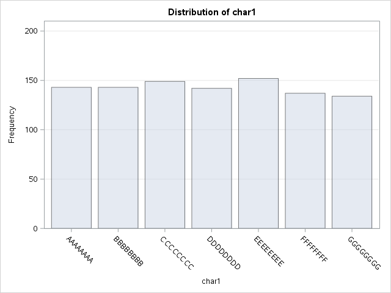

| char2 | Frequency | Percent | Cumulative Frequency | Cumulative Percent |
| --- | --- | --- | --- | --- |
| AAAAAAAA | 130 | 13.00 | 130 | 13.00 |
| BBBBBBBB | 135 | 13.50 | 265 | 26.50 |
| CCCCCCCC | 165 | 16.50 | 430 | 43.00 |
| DDDDDDDD | 141 | 14.10 | 571 | 57.10 |
| EEEEEEEE | 145 | 14.50 | 716 | 71.60 |
| FFFFFFFF | 142 | 14.20 | 858 | 85.80 |
| GGGGGGGG | 142 | 14.20 | 1000 | 100.00 |

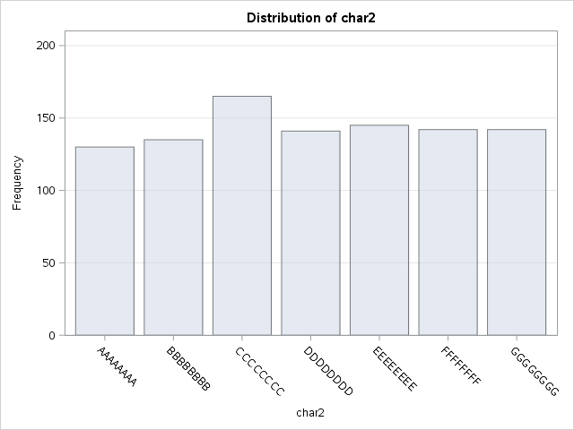

```sas
proc freq
    /* nlevels counts the discreet levels in each variable */
    /* the colon operator expands to include variable names with prefix char */
    data=scratch nlevels;
    /* request frequency bar charts for each variable */
    tables char: / plots=freqplot(type=bar);
run;
```

##### Use `PROC UNIVARIATE` to analyze numeric data

The SAS System

The UNIVARIATE Procedure

Variable: numeric1

| Moments |  |  |  |
| --- | --- | --- | --- |
| N | 1000 | Sum Weights | 1000 |
| Mean | 0.50633821 | Sum Observations | 506.33821 |
| Std Deviation | 0.28943761 | Variance | 0.08377413 |
| Skewness | -0.0121365 | Kurtosis | -1.2171282 |
| Uncorrected SS | 340.068739 | Corrected SS | 83.6903564 |
| Coeff Variation | 57.1629012 | Std Error Mean | 0.00915282 |

| Basic Statistical Measures Location | Basic Statistical Measures Location | Basic Statistical Measures Variability | Basic Statistical Measures Variability |
| --- | --- | --- | --- |
| Mean | 0.506338 | Std Deviation | 0.28944 |
| Median | 0.496667 | Variance | 0.08377 |
| Mode | . | Range | 0.99590 |
|  |  | Interquartile Range | 0.49767 |

| Tests for Location: Mu0=0 Test | Tests for Location: Mu0=0 Statistic | Tests for Location: Mu0=0 Statistic | Tests for Location: Mu0=0 p Value | Tests for Location: Mu0=0 p Value |
| --- | --- | --- | --- | --- |
| Student's t | t | 55.32045 | Pr > \|t\| | <.0001 |
| Sign | M | 500 | Pr >= \|M\| | <.0001 |
| Signed Rank | S | 250250 | Pr >= \|S\| | <.0001 |

| Quantiles (Definition 5) Level | Quantiles (Definition 5) Quantile |
| --- | --- |
| 100% Max | 0.99999473 |
| 99% | 0.98796014 |
| 95% | 0.94980769 |
| 90% | 0.90868125 |
| 75% Q3 | 0.76605127 |
| 50% Median | 0.49666691 |
| 25% Q1 | 0.26838609 |
| 10% | 0.10392146 |
| 5% | 0.05273732 |
| 1% | 0.01445704 |
| 0% Min | 0.00409347 |

| Extreme Observations Lowest Value | Extreme Observations Lowest Obs | Extreme Observations Highest Value | Extreme Observations Highest Obs |
| --- | --- | --- | --- |
| 0.00409347 | 215 | 0.994379 | 912 |
| 0.00433785 | 709 | 0.995267 | 483 |
| 0.00507468 | 729 | 0.996240 | 63 |
| 0.00610044 | 863 | 0.998160 | 191 |
| 0.00647425 | 498 | 0.999995 | 793 |

The SAS System

The UNIVARIATE Procedure

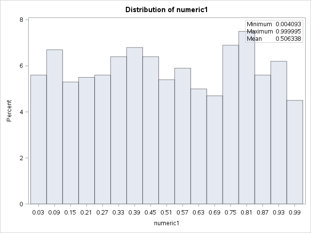

The SAS System

The UNIVARIATE Procedure

Variable: numeric2

| Moments |  |  |  |
| --- | --- | --- | --- |
| N | 1000 | Sum Weights | 1000 |
| Mean | 0.4982058 | Sum Observations | 498.205796 |
| Std Deviation | 0.2863714 | Variance | 0.08200858 |
| Skewness | 0.03568271 | Kurtosis | -1.1339161 |
| Uncorrected SS | 330.135587 | Corrected SS | 81.9265714 |
| Coeff Variation | 57.4805441 | Std Error Mean | 0.00905586 |

| Basic Statistical Measures Location | Basic Statistical Measures Location | Basic Statistical Measures Variability | Basic Statistical Measures Variability |
| --- | --- | --- | --- |
| Mean | 0.498206 | Std Deviation | 0.28637 |
| Median | 0.488096 | Variance | 0.08201 |
| Mode | . | Range | 0.99554 |
|  |  | Interquartile Range | 0.48204 |

| Tests for Location: Mu0=0 Test | Tests for Location: Mu0=0 Statistic | Tests for Location: Mu0=0 Statistic | Tests for Location: Mu0=0 p Value | Tests for Location: Mu0=0 p Value |
| --- | --- | --- | --- | --- |
| Student's t | t | 55.01475 | Pr > \|t\| | <.0001 |
| Sign | M | 500 | Pr >= \|M\| | <.0001 |
| Signed Rank | S | 250250 | Pr >= \|S\| | <.0001 |

| Quantiles (Definition 5) Level | Quantiles (Definition 5) Quantile |
| --- | --- |
| 100% Max | 0.99859106 |
| 99% | 0.99375025 |
| 95% | 0.95629616 |
| 90% | 0.90871284 |
| 75% Q3 | 0.74257851 |
| 50% Median | 0.48809598 |
| 25% Q1 | 0.26053719 |
| 10% | 0.10560284 |
| 5% | 0.04079423 |
| 1% | 0.01021775 |
| 0% Min | 0.00304634 |

| Extreme Observations Lowest Value | Extreme Observations Lowest Obs | Extreme Observations Highest Value | Extreme Observations Highest Obs |
| --- | --- | --- | --- |
| 0.00304634 | 72 | 0.995486 | 145 |
| 0.00450423 | 396 | 0.995995 | 888 |
| 0.00564384 | 87 | 0.996861 | 213 |
| 0.00698680 | 53 | 0.997395 | 355 |
| 0.00797265 | 395 | 0.998591 | 99 |

The SAS System

The UNIVARIATE Procedure

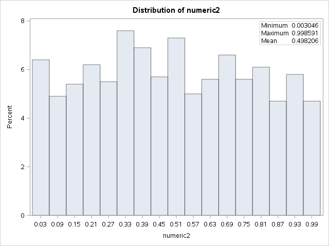

```sas
proc univariate
    data=scratch;
    /* request univariate statistics for variables names with prefix 'numeric'' */
    var numeric:;
    /* request histograms for the same variables */
    histogram numeric:;
    /* inset basic statistics on the histograms */
    inset min max mean / position=ne;
run;
```

## 4. Basic data manipulation

##### Subsetting data sets by column using data set options

```sas
* create scratch2 set;
data scratch2;
    /* set statement reads from a pre-existing data set */
    /* no output statement is required - this is more typical */
    /* using data set options: keep, drop, etc. is often more efficient than */
    /* corresponding data step statements */
    /* : notation */
    set scratch(keep=numeric:);
run;

* print first five rows;
proc print data=scratch2(obs=5); run;
```

The SAS System

| Obs | numeric1 | numeric2 |
| --- | --- | --- |
| 1 | 0.74519 | 0.27628 |
| 2 | 0.72888 | 0.73432 |
| 3 | 0.76408 | 0.18159 |
| 4 | 0.39360 | 0.85949 |
| 5 | 0.18129 | 0.23532 |

SAS `data` step supports in place overwrites of data

```sas
* overwrite scratch2 set;
data scratch2;
    /* ranges of vars specified using var<N> - var<M> syntax */
    set scratch(keep=char1-char&n_vars);
run;

* print first five rows;
proc print data=scratch2(obs=5); run;
```

The SAS System

| Obs | char1 | char2 |
| --- | --- | --- |
| 1 | CCCCCCCC | FFFFFFFF |
| 2 | BBBBBBBB | AAAAAAAA |
| 3 | EEEEEEEE | DDDDDDDD |
| 4 | BBBBBBBB | DDDDDDDD |
| 5 | CCCCCCCC | BBBBBBBB |

##### Subsetting data sets by column using variable names

```sas
* overwrite scratch2 set;
data scratch2;
    /* by name */
    set scratch(keep=key numeric1 char1);
run;

* print first five rows;
proc print data=scratch2(obs=5); run;
```

The SAS System

| Obs | key | char1 | numeric1 |
| --- | --- | --- | --- |
| 1 | 1 | CCCCCCCC | 0.74519 |
| 2 | 2 | BBBBBBBB | 0.72888 |
| 3 | 3 | EEEEEEEE | 0.76408 |
| 4 | 4 | BBBBBBBB | 0.39360 |
| 5 | 5 | CCCCCCCC | 0.18129 |

##### Subset and modify columns

```sas
* select two columns and modify them with data step functions;
* overwrite scratch2 set;
data scratch2;
    /* use length statement to ensure correct length of trans_char1 */
    /* the lag function saves the value from the row above */
    /* lag will create a numeric missing ('.') value in the first row */
    /* tranwrd finds and replaces character values */
    set scratch(keep=key char1 numeric1
        rename=(char1=new_char1 numeric1=new_numeric1));
    length trans_char1 $8;
    lag_numeric1 = lag(new_numeric1);
    trans_char1 = tranwrd(new_char1, 'GGGGGGGG', 'foo');
run;

* print first five rows;
* notice that '.' represents numeric missing in SAS;
proc print data=scratch2(obs=5); run;
```

The SAS System

| Obs | key | new_char1 | new_numeric1 | trans_char1 | lag_numeric1 |
| --- | --- | --- | --- | --- | --- |
| 1 | 1 | CCCCCCCC | 0.74519 | CCCCCCCC | . |
| 2 | 2 | BBBBBBBB | 0.72888 | BBBBBBBB | 0.74519 |
| 3 | 3 | EEEEEEEE | 0.76408 | EEEEEEEE | 0.72888 |
| 4 | 4 | BBBBBBBB | 0.39360 | BBBBBBBB | 0.76408 |
| 5 | 5 | CCCCCCCC | 0.18129 | CCCCCCCC | 0.39360 |

##### Subsetting rows using the `where` data set option

```sas
* select only the first row and impute the missing value;
* create scratch3 set;
data scratch3;
    /* the where data set option can subset rows of data sets */
    /* there are MANY other ways to do this ... */
    set scratch2 (where=(key=1));
    lag_numeric1 = 0;
run;

* print;
proc print data=scratch3; run;
```

The SAS System

| Obs | key | new_char1 | new_numeric1 | trans_char1 | lag_numeric1 |
| --- | --- | --- | --- | --- | --- |
| 1 | 1 | CCCCCCCC | 0.74519 | CCCCCCCC | 0 |

##### Subsetting rows using `data` step statements

```sas
* remove the problematic first row containing the missing value;
* from scratch2 set;
data scratch2;
    set scratch2;
    if key > 1;
run;

* print first five rows;
proc print data=scratch2(obs=5); run;
```

The SAS System

| Obs | key | new_char1 | new_numeric1 | trans_char1 | lag_numeric1 |
| --- | --- | --- | --- | --- | --- |
| 1 | 2 | BBBBBBBB | 0.72888 | BBBBBBBB | 0.74519 |
| 2 | 3 | EEEEEEEE | 0.76408 | EEEEEEEE | 0.72888 |
| 3 | 4 | BBBBBBBB | 0.39360 | BBBBBBBB | 0.76408 |
| 4 | 5 | CCCCCCCC | 0.18129 | CCCCCCCC | 0.39360 |
| 5 | 6 | BBBBBBBB | 0.56993 | BBBBBBBB | 0.18129 |

##### Combining data sets top-to-bottom using `PROC APPEND`

```sas
* add scratch3 to the bottom of scratch2;
proc append
    base=scratch2  /* proc append does not read the base set */
    data=scratch3; /* for performance reasons base set should be largest */
run;
```

```
271  ods listing close;ods html5 file=stdout options(bitmap_mode='inline') device=png; ods graphics on / outputfmt=png;
NOTE: Writing HTML5 Body file: STDOUT
272
273  * add scratch3 to the bottom of scratch2;
274  proc append
275      base=scratch2  /* proc append does not read the base set */
276      data=scratch3; /* for performance reasons base set should be largest */
277  run;
NOTE: Appending WORK.SCRATCH3 to WORK.SCRATCH2.
NOTE: There were 1 observations read from the data set WORK.SCRATCH3.
NOTE: 1 observations added.
NOTE: The data set WORK.SCRATCH2 has 1000 observations and 5 variables.
NOTE: PROCEDURE APPEND used (Total process time):
      real time           0.00 seconds
      cpu time            0.00 seconds

278  ods html5 close;ods listing;

279
```

##### Sorting data sets using `PROC SORT`

```sas
* sort scratch2 in place;
proc sort
    data=scratch2;
    by key; /* you must specificy a variables to sort by */
run;

* print first five rows;
proc print data=scratch2(obs=5); run;
```

The SAS System

| Obs | key | new_char1 | new_numeric1 | trans_char1 | lag_numeric1 |
| --- | --- | --- | --- | --- | --- |
| 1 | 1 | CCCCCCCC | 0.74519 | CCCCCCCC | 0.00000 |
| 2 | 2 | BBBBBBBB | 0.72888 | BBBBBBBB | 0.74519 |
| 3 | 3 | EEEEEEEE | 0.76408 | EEEEEEEE | 0.72888 |
| 4 | 4 | BBBBBBBB | 0.39360 | BBBBBBBB | 0.76408 |
| 5 | 5 | CCCCCCCC | 0.18129 | CCCCCCCC | 0.39360 |

```sas
* create the new scratch4 set;
proc sort
    data=scratch2
    out=scratch4; /* specifying an out set creates a new data set */
    by new_char1 new_numeric1; /* you can sort by many variables */
run;

* print first five rows;
proc print data=scratch4(obs=5); run;
```

The SAS System

| Obs | key | new_char1 | new_numeric1 | trans_char1 | lag_numeric1 |
| --- | --- | --- | --- | --- | --- |
| 1 | 729 | AAAAAAAA | 0.005075 | AAAAAAAA | 0.71008 |
| 2 | 370 | AAAAAAAA | 0.012808 | AAAAAAAA | 0.40257 |
| 3 | 965 | AAAAAAAA | 0.029816 | AAAAAAAA | 0.79305 |
| 4 | 758 | AAAAAAAA | 0.043995 | AAAAAAAA | 0.77802 |
| 5 | 383 | AAAAAAAA | 0.064970 | AAAAAAAA | 0.39526 |

##### Combining data sets side-by-side using the `data` step `merge` statement

```sas
* combining data sets side-by-side;
* to create messy scratch5 set;
data scratch5;
    /* merge simply attaches two or more data sets together side-by-side*/
    /* it overwrites common variables - be careful */
    merge scratch scratch4;
run;

* print first five rows;
proc print data=scratch5(obs=5); run;
```

The SAS System

| Obs | key | char1 | char2 | numeric1 | numeric2 | new_char1 | new_numeric1 | trans_char1 | lag_numeric1 |
| --- | --- | --- | --- | --- | --- | --- | --- | --- | --- |
| 1 | 729 | CCCCCCCC | FFFFFFFF | 0.74519 | 0.27628 | AAAAAAAA | 0.005075 | AAAAAAAA | 0.71008 |
| 2 | 370 | BBBBBBBB | AAAAAAAA | 0.72888 | 0.73432 | AAAAAAAA | 0.012808 | AAAAAAAA | 0.40257 |
| 3 | 965 | EEEEEEEE | DDDDDDDD | 0.76408 | 0.18159 | AAAAAAAA | 0.029816 | AAAAAAAA | 0.79305 |
| 4 | 758 | BBBBBBBB | DDDDDDDD | 0.39360 | 0.85949 | AAAAAAAA | 0.043995 | AAAAAAAA | 0.77802 |
| 5 | 383 | CCCCCCCC | BBBBBBBB | 0.18129 | 0.23532 | AAAAAAAA | 0.064970 | AAAAAAAA | 0.39526 |

```sas
* join columns to scratch from scratch2 when key variable matches;
* to create scratch6 correctly;
data scratch6;
    /* merging with a by variable is safer */
    /* it requires that both sets be sorted */
    /* then rows are matched when key values are equal */
    /* very similar to SQL join */
    merge scratch scratch2;
    by key;
run;

* print first five rows;
proc print data=scratch6(obs=5); run;
```

The SAS System

| Obs | key | char1 | char2 | numeric1 | numeric2 | new_char1 | new_numeric1 | trans_char1 | lag_numeric1 |
| --- | --- | --- | --- | --- | --- | --- | --- | --- | --- |
| 1 | 1 | CCCCCCCC | FFFFFFFF | 0.74519 | 0.27628 | CCCCCCCC | 0.74519 | CCCCCCCC | 0.00000 |
| 2 | 2 | BBBBBBBB | AAAAAAAA | 0.72888 | 0.73432 | BBBBBBBB | 0.72888 | BBBBBBBB | 0.74519 |
| 3 | 3 | EEEEEEEE | DDDDDDDD | 0.76408 | 0.18159 | EEEEEEEE | 0.76408 | EEEEEEEE | 0.72888 |
| 4 | 4 | BBBBBBBB | DDDDDDDD | 0.39360 | 0.85949 | BBBBBBBB | 0.39360 | BBBBBBBB | 0.76408 |
| 5 | 5 | CCCCCCCC | BBBBBBBB | 0.18129 | 0.23532 | CCCCCCCC | 0.18129 | CCCCCCCC | 0.39360 |

##### Combining data sets side-by-side using `PROC SQL`

`PROC SQL` allows the execution of SQL statements inside a SAS session

```sas
* nearly all common SQL statements and functions are supported by PROC SQL;
* join columns to scratch from scratch2 when key variable matches;
* to create scratch7 correctly;
proc sql noprint; /* noprint suppresses procedure output */
    create table scratch7 as
    select *
    from scratch
    join scratch2
    on scratch.key = scratch2.key;
quit;

* print first five rows;
proc print data=scratch7(obs=5); run;
```

The SAS System

| Obs | key | char1 | char2 | numeric1 | numeric2 | new_char1 | new_numeric1 | trans_char1 | lag_numeric1 |
| --- | --- | --- | --- | --- | --- | --- | --- | --- | --- |
| 1 | 1 | CCCCCCCC | FFFFFFFF | 0.74519 | 0.27628 | CCCCCCCC | 0.74519 | CCCCCCCC | 0.00000 |
| 2 | 2 | BBBBBBBB | AAAAAAAA | 0.72888 | 0.73432 | BBBBBBBB | 0.72888 | BBBBBBBB | 0.74519 |
| 3 | 3 | EEEEEEEE | DDDDDDDD | 0.76408 | 0.18159 | EEEEEEEE | 0.76408 | EEEEEEEE | 0.72888 |
| 4 | 4 | BBBBBBBB | DDDDDDDD | 0.39360 | 0.85949 | BBBBBBBB | 0.39360 | BBBBBBBB | 0.76408 |
| 5 | 5 | CCCCCCCC | BBBBBBBB | 0.18129 | 0.23532 | CCCCCCCC | 0.18129 | CCCCCCCC | 0.39360 |

##### Comparing data sets using `PROC COMPARE`

```sas
* results from data step merge with by variable and PROC SQL join;
* should be equal;
proc compare base=scratch6 compare=scratch7;
run;
```

The SAS System

```
                                                       The COMPARE Procedure
                                           Comparison of WORK.SCRATCH6 with WORK.SCRATCH7
                                                           (Method=EXACT)

                                                         Data Set Summary

                                  Dataset                 Created          Modified  NVar    NObs

                                  WORK.SCRATCH6  22NOV16:19:35:24  22NOV16:19:35:24     9    1000
                                  WORK.SCRATCH7  22NOV16:19:35:24  22NOV16:19:35:24     9    1000


                                                         Variables Summary

                                               Number of Variables in Common: 9.
```

```
                                                        Observation Summary

                                                   Observation      Base  Compare

                                                   First Obs           1        1
                                                   Last  Obs        1000     1000

                                  Number of Observations in Common: 1000.
                                  Total Number of Observations Read from WORK.SCRATCH6: 1000.
                                  Total Number of Observations Read from WORK.SCRATCH7: 1000.

                                  Number of Observations with Some Compared Variables Unequal: 0.
                                  Number of Observations with All Compared Variables Equal: 1000.

                                  NOTE: No unequal values were found. All values compared are exactly equal.
```

##### Export data using `PROC EXPORT`

```sas
* export data set to create a csv file;
* to default directory;
proc export
    data=scratch7
    outfile='scratch.csv'
    dbms=csv
    /* replace an existing file with that name */
    replace;
run;
```

```
593  ods listing close;ods html5 file=stdout options(bitmap_mode='inline') device=png; ods graphics on / outputfmt=png;
NOTE: Writing HTML5 Body file: STDOUT
594
595  * export data set to create a csv file;
596  * to default directory;
597  proc export
598      data=scratch7
599      outfile='scratch.csv'
600      dbms=csv
601      /* replace an existing file with that name */
602      replace;
603  run;
604   /**********************************************************************
605   *   PRODUCT:   SAS
606   *   VERSION:   9.4
```

[output cut: 82 more lines]

##### Import data using `PROC IMPORT`

```sas
* import data set;
* from default directory;
* from the csv file;
* to overwrite scratch7 set;
proc import
    /* import from scratch7.csv */
    datafile='scratch.csv'
    /* create a sas table in the work library */
    out=scratch7
    /* from a csv file */
    dbms=csv
    /* replace an existing data set with that name */
    replace;
run;
```

```
442  ods listing close;ods html5 file=stdout options(bitmap_mode='inline') device=png; ods graphics on / outputfmt=png;
NOTE: Writing HTML5 Body file: STDOUT
443
444  * import data set;
445  * from default directory;
446  * from the csv file;
447  * to overwrite scratch7 set;
448  proc import
449      /* import from scratch7.csv */
450      datafile='scratch.csv'
451      /* create a sas table in the work library */
452      out=scratch7
453      /* from a csv file */
454      dbms=csv
455      /* replace an existing data set with that name */
456      replace;
457  run;
458   /**********************************************************************
459   *   PRODUCT:   SAS
460   *   VERSION:   9.4
461   *   CREATOR:   External File Interface
462   *   DATE:      22NOV16
463   *   DESC:      Generated SAS Datastep Code
464   *   TEMPLATE SOURCE:  (None Specified.)
465   ***********************************************************************/
466      data WORK.SCRATCH7    ;
467      %let _EFIERR_ = 0; /* set the ERROR detection macro variable */
468      infile 'scratch.csv' delimiter = ',' MISSOVER DSD lrecl=32767 firstobs=2 ;
469         informat key best32. ;
470         informat char1 $8. ;
471         informat char2 $8. ;
472         informat numeric1 best32. ;
473         informat numeric2 best32. ;
474         informat new_char1 $8. ;
475         informat new_numeric1 best32. ;
476         informat trans_char1 $8. ;
477         informat lag_numeric1 best32. ;
478         format key best12. ;
479         format char1 $8. ;
480         format char2 $8. ;
```

[output cut: 32 more lines]

```
      cpu time            0.00 seconds

1000 rows created in WORK.SCRATCH7 from scratch.csv.



NOTE: WORK.SCRATCH7 data set was successfully created.
NOTE: The data set WORK.SCRATCH7 has 1000 observations and 9 variables.
NOTE: PROCEDURE IMPORT used (Total process time):
      real time           0.03 seconds
      cpu time            0.03 seconds

500  ods html5 close;ods listing;

501
```

##### By group processing in the `data` step

```sas
* by variables can be used in the data step;
* the data set must be sorted;
* create scratch8 summary set;
data scratch8;
    set scratch4;
    by new_char1 new_numeric1;
    retain count 0; /* retained variables are remembered from row-to-row */
    if last.new_char1 then do; /* first. and last. can be used with by vars */
        count + 1; /* shorthand to increment a retained variable */
        output; /* output the last row of a sorted by group */
    end;
run;

* using PROC PRINT without the data= option prints the most recent set;
proc print; run;
```

The SAS System

| Obs | key | new_char1 | new_numeric1 | trans_char1 | lag_numeric1 | count |
| --- | --- | --- | --- | --- | --- | --- |
| 1 | 962 | AAAAAAAA | 0.99264 | AAAAAAAA | 0.07529 | 1 |
| 2 | 201 | BBBBBBBB | 0.98891 | BBBBBBBB | 0.71665 | 2 |
| 3 | 191 | CCCCCCCC | 0.99816 | CCCCCCCC | 0.84966 | 3 |
| 4 | 597 | DDDDDDDD | 0.98891 | DDDDDDDD | 0.82614 | 4 |
| 5 | 793 | EEEEEEEE | 0.99999 | EEEEEEEE | 0.11873 | 5 |
| 6 | 63 | FFFFFFFF | 0.99624 | FFFFFFFF | 0.02960 | 6 |
| 7 | 456 | GGGGGGGG | 0.97751 | foo | 0.28907 | 7 |

##### By group processing in SAS procedures

The SAS System

The UNIVARIATE Procedure

Variable: lag_numeric1

new_char1=AAAAAAAA

| Moments |  |  |  |
| --- | --- | --- | --- |
| N | 143 | Sum Weights | 143 |
| Mean | 0.49071887 | Sum Observations | 70.1727988 |
| Std Deviation | 0.29483857 | Variance | 0.08692978 |
| Skewness | 0.13096455 | Kurtosis | -1.2282289 |
| Uncorrected SS | 46.7791457 | Corrected SS | 12.3440289 |
| Coeff Variation | 60.0829894 | Std Error Mean | 0.02465564 |

| Basic Statistical Measures Location | Basic Statistical Measures Location | Basic Statistical Measures Variability | Basic Statistical Measures Variability |
| --- | --- | --- | --- |
| Mean | 0.490719 | Std Deviation | 0.29484 |
| Median | 0.430797 | Variance | 0.08693 |
| Mode | . | Range | 0.98457 |
|  |  | Interquartile Range | 0.52836 |

| Tests for Location: Mu0=0 Test | Tests for Location: Mu0=0 Statistic | Tests for Location: Mu0=0 Statistic | Tests for Location: Mu0=0 p Value | Tests for Location: Mu0=0 p Value |
| --- | --- | --- | --- | --- |
| Student's t | t | 19.90291 | Pr > \|t\| | <.0001 |
| Sign | M | 71.5 | Pr >= \|M\| | <.0001 |
| Signed Rank | S | 5148 | Pr >= \|S\| | <.0001 |

| Quantiles (Definition 5) Level | Quantiles (Definition 5) Quantile |
| --- | --- |
| 100% Max | 0.98890576 |
| 99% | 0.98655522 |
| 95% | 0.96006550 |
| 90% | 0.92620130 |
| 75% Q3 | 0.77802470 |
| 50% Median | 0.43079665 |
| 25% Q1 | 0.24966709 |
| 10% | 0.10271068 |
| 5% | 0.06484634 |
| 1% | 0.00610044 |
| 0% Min | 0.00433785 |

| Extreme Observations Lowest Value | Extreme Observations Lowest Obs | Extreme Observations Highest Value | Extreme Observations Highest Obs |
| --- | --- | --- | --- |
| 0.00433785 | 117 | 0.967188 | 34 |
| 0.00610044 | 75 | 0.974507 | 16 |
| 0.00647425 | 49 | 0.978504 | 99 |
| 0.01405615 | 126 | 0.986555 | 62 |
| 0.02457284 | 9 | 0.988906 | 18 |

The SAS System

The UNIVARIATE Procedure

new_char1=AAAAAAAA

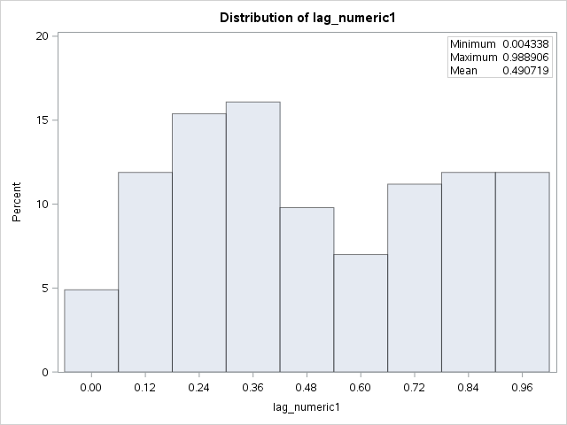

The SAS System

The UNIVARIATE Procedure

Variable: lag_numeric1

new_char1=BBBBBBBB

| Moments |  |  |  |
| --- | --- | --- | --- |
| N | 143 | Sum Weights | 143 |
| Mean | 0.53527493 | Sum Observations | 76.544315 |
| Std Deviation | 0.29608721 | Variance | 0.08766764 |
| Skewness | -0.1741468 | Kurtosis | -1.2955583 |
| Uncorrected SS | 53.4210573 | Corrected SS | 12.4488044 |
| Coeff Variation | 55.3149782 | Std Error Mean | 0.02476006 |

| Basic Statistical Measures Location | Basic Statistical Measures Location | Basic Statistical Measures Variability | Basic Statistical Measures Variability |
| --- | --- | --- | --- |
| Mean | 0.535275 | Std Deviation | 0.29609 |
| Median | 0.548172 | Variance | 0.08767 |
| Mode | . | Range | 0.97268 |
|  |  | Interquartile Range | 0.55076 |

| Tests for Location: Mu0=0 Test | Tests for Location: Mu0=0 Statistic | Tests for Location: Mu0=0 Statistic | Tests for Location: Mu0=0 p Value | Tests for Location: Mu0=0 p Value |
| --- | --- | --- | --- | --- |
| Student's t | t | 21.61849 | Pr > \|t\| | <.0001 |
| Sign | M | 71.5 | Pr >= \|M\| | <.0001 |
| Signed Rank | S | 5148 | Pr >= \|S\| | <.0001 |

| Quantiles (Definition 5) Level | Quantiles (Definition 5) Quantile |
| --- | --- |
| 100% Max | 0.9856062 |
| 99% | 0.9844003 |
| 95% | 0.9629953 |
| 90% | 0.9016123 |
| 75% Q3 | 0.8079205 |
| 50% Median | 0.5481721 |
| 25% Q1 | 0.2571620 |
| 10% | 0.1145349 |
| 5% | 0.0580258 |
| 1% | 0.0193226 |
| 0% Min | 0.0129249 |

| Extreme Observations Lowest Value | Extreme Observations Lowest Obs | Extreme Observations Highest Value | Extreme Observations Highest Obs |
| --- | --- | --- | --- |
| 0.0129249 | 276 | 0.968072 | 222 |
| 0.0193226 | 248 | 0.973458 | 170 |
| 0.0296455 | 189 | 0.981268 | 269 |
| 0.0392363 | 174 | 0.984400 | 282 |
| 0.0431449 | 210 | 0.985606 | 278 |

The SAS System

The UNIVARIATE Procedure

new_char1=BBBBBBBB

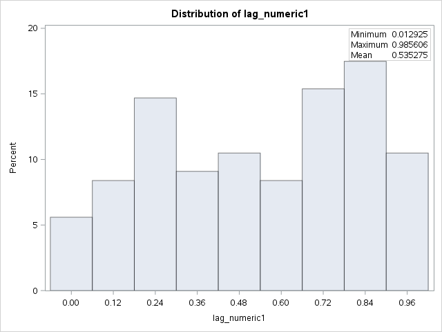

The SAS System

The UNIVARIATE Procedure

Variable: lag_numeric1

new_char1=CCCCCCCC

| Moments |  |  |  |
| --- | --- | --- | --- |
| N | 149 | Sum Weights | 149 |
| Mean | 0.51844134 | Sum Observations | 77.2477597 |
| Std Deviation | 0.30300948 | Variance | 0.09181474 |
| Skewness | -0.0848525 | Kurtosis | -1.2553408 |
| Uncorrected SS | 53.637014 | Corrected SS | 13.5885819 |
| Coeff Variation | 58.4462411 | Std Error Mean | 0.0248235 |

| Basic Statistical Measures Location | Basic Statistical Measures Location | Basic Statistical Measures Variability | Basic Statistical Measures Variability |
| --- | --- | --- | --- |
| Mean | 0.518441 | Std Deviation | 0.30301 |
| Median | 0.545160 | Variance | 0.09181 |
| Mode | . | Range | 0.99367 |
|  |  | Interquartile Range | 0.52698 |

| Tests for Location: Mu0=0 Test | Tests for Location: Mu0=0 Statistic | Tests for Location: Mu0=0 Statistic | Tests for Location: Mu0=0 p Value | Tests for Location: Mu0=0 p Value |
| --- | --- | --- | --- | --- |
| Student's t | t | 20.8851 | Pr > \|t\| | <.0001 |
| Sign | M | 74 | Pr >= \|M\| | <.0001 |
| Signed Rank | S | 5513 | Pr >= \|S\| | <.0001 |

| Quantiles (Definition 5) Level | Quantiles (Definition 5) Quantile |
| --- | --- |
| 100% Max | 0.99366507 |
| 99% | 0.99113039 |
| 95% | 0.97016056 |
| 90% | 0.93772714 |
| 75% Q3 | 0.78893718 |
| 50% Median | 0.54515967 |
| 25% Q1 | 0.26196195 |
| 10% | 0.09154551 |
| 5% | 0.03813221 |
| 1% | 0.00507468 |
| 0% Min | 0.00000000 |

| Extreme Observations Lowest Value | Extreme Observations Lowest Obs | Extreme Observations Highest Value | Extreme Observations Highest Obs |
| --- | --- | --- | --- |
| 0.00000000 | 402 | 0.981746 | 289 |
| 0.00507468 | 429 | 0.984780 | 384 |
| 0.01014111 | 361 | 0.987015 | 303 |
| 0.01629693 | 291 | 0.991130 | 382 |
| 0.01898068 | 378 | 0.993665 | 298 |

The SAS System

The UNIVARIATE Procedure

new_char1=CCCCCCCC

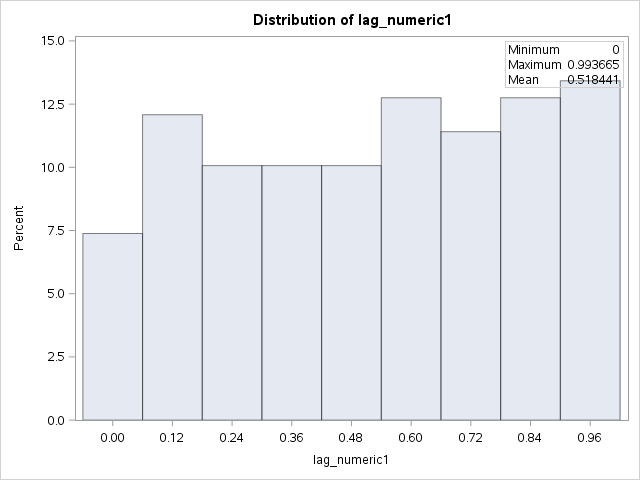

The SAS System

The UNIVARIATE Procedure

Variable: lag_numeric1

new_char1=DDDDDDDD

| Moments |  |  |  |
| --- | --- | --- | --- |
| N | 142 | Sum Weights | 142 |
| Mean | 0.5209562 | Sum Observations | 73.9757808 |
| Std Deviation | 0.28497267 | Variance | 0.08120942 |
| Skewness | -0.2170349 | Kurtosis | -1.1551723 |
| Uncorrected SS | 49.9886703 | Corrected SS | 11.4505284 |
| Coeff Variation | 54.7018476 | Std Error Mean | 0.02391438 |

| Basic Statistical Measures Location | Basic Statistical Measures Location | Basic Statistical Measures Variability | Basic Statistical Measures Variability |
| --- | --- | --- | --- |
| Mean | 0.520956 | Std Deviation | 0.28497 |
| Median | 0.578337 | Variance | 0.08121 |
| Mode | . | Range | 0.98069 |
|  |  | Interquartile Range | 0.50251 |

| Tests for Location: Mu0=0 Test | Tests for Location: Mu0=0 Statistic | Tests for Location: Mu0=0 Statistic | Tests for Location: Mu0=0 p Value | Tests for Location: Mu0=0 p Value |
| --- | --- | --- | --- | --- |
| Student's t | t | 21.78423 | Pr > \|t\| | <.0001 |
| Sign | M | 71 | Pr >= \|M\| | <.0001 |
| Signed Rank | S | 5076.5 | Pr >= \|S\| | <.0001 |

| Quantiles (Definition 5) Level | Quantiles (Definition 5) Quantile |
| --- | --- |
| 100% Max | 0.98477907 |
| 99% | 0.97048743 |
| 95% | 0.92748484 |
| 90% | 0.89918963 |
| 75% Q3 | 0.75668994 |
| 50% Median | 0.57833705 |
| 25% Q1 | 0.25417622 |
| 10% | 0.08992516 |
| 5% | 0.05752626 |
| 1% | 0.01591177 |
| 0% Min | 0.00409347 |

| Extreme Observations Lowest Value | Extreme Observations Lowest Obs | Extreme Observations Highest Value | Extreme Observations Highest Obs |
| --- | --- | --- | --- |
| 0.00409347 | 530 | 0.935270 | 491 |
| 0.01591177 | 504 | 0.953484 | 445 |
| 0.03219571 | 529 | 0.969972 | 537 |
| 0.03317137 | 439 | 0.970487 | 559 |
| 0.04476607 | 572 | 0.984779 | 521 |

The SAS System

The UNIVARIATE Procedure

new_char1=DDDDDDDD

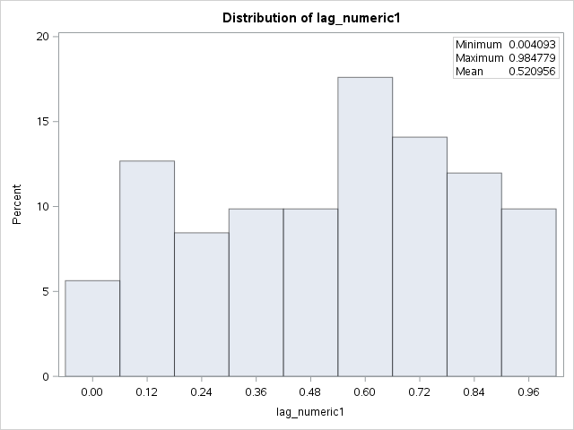

The SAS System

The UNIVARIATE Procedure

Variable: lag_numeric1

new_char1=EEEEEEEE

| Moments |  |  |  |
| --- | --- | --- | --- |
| N | 152 | Sum Weights | 152 |
| Mean | 0.50392372 | Sum Observations | 76.5964058 |
| Std Deviation | 0.30547624 | Variance | 0.09331573 |
| Skewness | 0.05104127 | Kurtosis | -1.359438 |
| Uncorrected SS | 52.6894218 | Corrected SS | 14.0906759 |
| Coeff Variation | 60.6195399 | Std Error Mean | 0.0247774 |

| Basic Statistical Measures Location | Basic Statistical Measures Location | Basic Statistical Measures Variability | Basic Statistical Measures Variability |
| --- | --- | --- | --- |
| Mean | 0.503924 | Std Deviation | 0.30548 |
| Median | 0.472996 | Variance | 0.09332 |
| Mode | . | Range | 0.97934 |
|  |  | Interquartile Range | 0.56091 |

| Tests for Location: Mu0=0 Test | Tests for Location: Mu0=0 Statistic | Tests for Location: Mu0=0 Statistic | Tests for Location: Mu0=0 p Value | Tests for Location: Mu0=0 p Value |
| --- | --- | --- | --- | --- |
| Student's t | t | 20.33804 | Pr > \|t\| | <.0001 |
| Sign | M | 76 | Pr >= \|M\| | <.0001 |
| Signed Rank | S | 5814 | Pr >= \|S\| | <.0001 |

| Quantiles (Definition 5) Level | Quantiles (Definition 5) Quantile |
| --- | --- |
| 100% Max | 0.9999947 |
| 99% | 0.9981595 |
| 95% | 0.9686054 |
| 90% | 0.9213424 |
| 75% Q3 | 0.7869107 |
| 50% Median | 0.4729956 |
| 25% Q1 | 0.2260008 |
| 10% | 0.1094131 |
| 5% | 0.0597403 |
| 1% | 0.0274655 |
| 0% Min | 0.0206584 |

| Extreme Observations Lowest Value | Extreme Observations Lowest Obs | Extreme Observations Highest Value | Extreme Observations Highest Obs |
| --- | --- | --- | --- |
| 0.0206584 | 647 | 0.988909 | 636 |
| 0.0274655 | 648 | 0.994379 | 674 |
| 0.0339727 | 609 | 0.995267 | 723 |
| 0.0349232 | 651 | 0.998160 | 678 |
| 0.0376134 | 664 | 0.999995 | 721 |

The SAS System

The UNIVARIATE Procedure

new_char1=EEEEEEEE

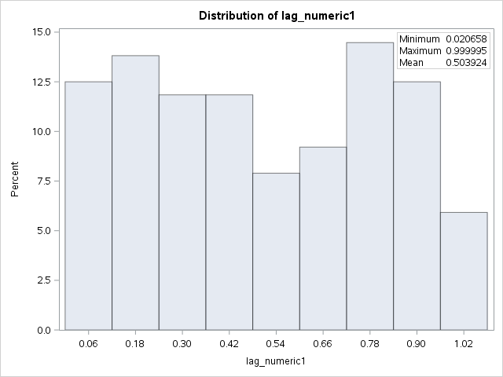

The SAS System

The UNIVARIATE Procedure

Variable: lag_numeric1

new_char1=FFFFFFFF

| Moments |  |  |  |
| --- | --- | --- | --- |
| N | 137 | Sum Weights | 137 |
| Mean | 0.48863056 | Sum Observations | 66.9423872 |
| Std Deviation | 0.27619572 | Variance | 0.07628408 |
| Skewness | -0.0498362 | Kurtosis | -1.0731154 |
| Uncorrected SS | 43.084731 | Corrected SS | 10.3746346 |
| Coeff Variation | 56.524447 | Std Error Mean | 0.02359699 |

| Basic Statistical Measures Location | Basic Statistical Measures Location | Basic Statistical Measures Variability | Basic Statistical Measures Variability |
| --- | --- | --- | --- |
| Mean | 0.488631 | Std Deviation | 0.27620 |
| Median | 0.475913 | Variance | 0.07628 |
| Mode | . | Range | 0.98572 |
|  |  | Interquartile Range | 0.44419 |

| Tests for Location: Mu0=0 Test | Tests for Location: Mu0=0 Statistic | Tests for Location: Mu0=0 Statistic | Tests for Location: Mu0=0 p Value | Tests for Location: Mu0=0 p Value |
| --- | --- | --- | --- | --- |
| Student's t | t | 20.70732 | Pr > \|t\| | <.0001 |
| Sign | M | 68.5 | Pr >= \|M\| | <.0001 |
| Signed Rank | S | 4726.5 | Pr >= \|S\| | <.0001 |

| Quantiles (Definition 5) Level | Quantiles (Definition 5) Quantile |
| --- | --- |
| 100% Max | 0.9962396 |
| 99% | 0.9734552 |
| 95% | 0.9105424 |
| 90% | 0.8545792 |
| 75% Q3 | 0.7400244 |
| 50% Median | 0.4759132 |
| 25% Q1 | 0.2958376 |
| 10% | 0.0941431 |
| 5% | 0.0296041 |
| 1% | 0.0128085 |
| 0% Min | 0.0105241 |

| Extreme Observations Lowest Value | Extreme Observations Lowest Obs | Extreme Observations Highest Value | Extreme Observations Highest Obs |
| --- | --- | --- | --- |
| 0.0105241 | 785 | 0.920413 | 766 |
| 0.0128085 | 746 | 0.949874 | 786 |
| 0.0155565 | 800 | 0.966347 | 845 |
| 0.0165746 | 838 | 0.973455 | 806 |
| 0.0184293 | 801 | 0.996240 | 813 |

The SAS System

The UNIVARIATE Procedure

new_char1=FFFFFFFF

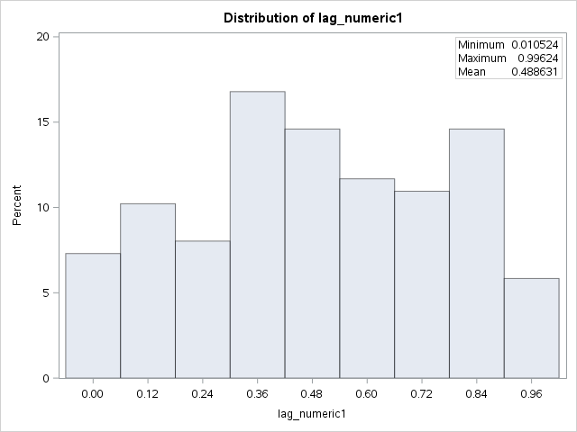

The SAS System

The UNIVARIATE Procedure

Variable: lag_numeric1

new_char1=GGGGGGGG

| Moments |  |  |  |
| --- | --- | --- | --- |
| N | 134 | Sum Weights | 134 |
| Mean | 0.48282754 | Sum Observations | 64.69889 |
| Std Deviation | 0.26307513 | Variance | 0.06920853 |
| Skewness | 0.23125403 | Kurtosis | -0.9008902 |
| Uncorrected SS | 40.4431397 | Corrected SS | 9.20473394 |
| Coeff Variation | 54.4863566 | Std Error Mean | 0.02272623 |

| Basic Statistical Measures Location | Basic Statistical Measures Location | Basic Statistical Measures Variability | Basic Statistical Measures Variability |
| --- | --- | --- | --- |
| Mean | 0.482828 | Std Deviation | 0.26308 |
| Median | 0.451759 | Variance | 0.06921 |
| Mode | . | Range | 0.97778 |
|  |  | Interquartile Range | 0.40099 |

| Tests for Location: Mu0=0 Test | Tests for Location: Mu0=0 Statistic | Tests for Location: Mu0=0 Statistic | Tests for Location: Mu0=0 p Value | Tests for Location: Mu0=0 p Value |
| --- | --- | --- | --- | --- |
| Student's t | t | 21.24539 | Pr > \|t\| | <.0001 |
| Sign | M | 67 | Pr >= \|M\| | <.0001 |
| Signed Rank | S | 4522.5 | Pr >= \|S\| | <.0001 |

| Quantiles (Definition 5) Level | Quantiles (Definition 5) Quantile |
| --- | --- |
| 100% Max | 0.9926352 |
| 99% | 0.9775109 |
| 95% | 0.9349751 |
| 90% | 0.8826924 |
| 75% Q3 | 0.7133919 |
| 50% Median | 0.4517587 |
| 25% Q1 | 0.3123979 |
| 10% | 0.1230748 |
| 5% | 0.0749330 |
| 1% | 0.0296565 |
| 0% Min | 0.0148579 |

| Extreme Observations Lowest Value | Extreme Observations Lowest Obs | Extreme Observations Highest Value | Extreme Observations Highest Obs |
| --- | --- | --- | --- |
| 0.0148579 | 895 | 0.957998 | 881 |
| 0.0296565 | 982 | 0.966782 | 975 |
| 0.0483612 | 922 | 0.976707 | 986 |
| 0.0515094 | 889 | 0.977511 | 944 |
| 0.0538630 | 894 | 0.992635 | 917 |

The SAS System

The UNIVARIATE Procedure

new_char1=GGGGGGGG

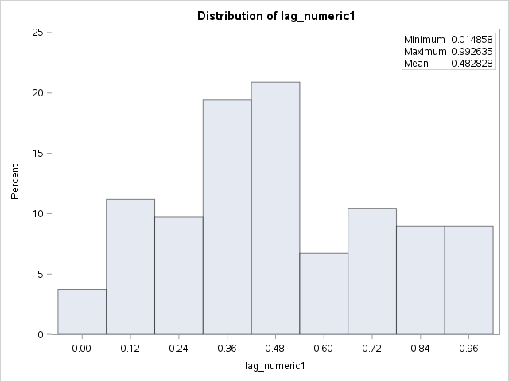

```sas
* by variables can be used efficiently in most procedures;
* the data set must be sorted;
proc univariate
    data=scratch4;
    var lag_numeric1;
    histogram lag_numeric1;
    inset min max mean / position=ne;
    by new_char1;
run;
```

## 5. Generating plots with `PROC SGPLOT`

##### Histograms with PROC SGPLOT

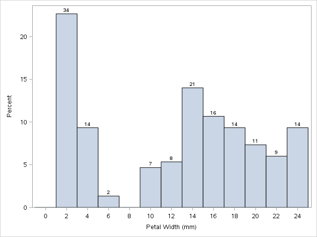

```sas
proc sgplot
    /* sashelp.iris is a sample data set */
    /* binwidth - bin width in terms of histogram variable */
    /* datalabel - display counts or percents for each bin */
    /* showbins - use bins to determine x-axis tickmarks */
    data=sashelp.iris;
    histogram petalwidth /
        binwidth=2
        datalabel=count
        showbins;
run;
```

##### Bubble plots with PROC SGPLOT

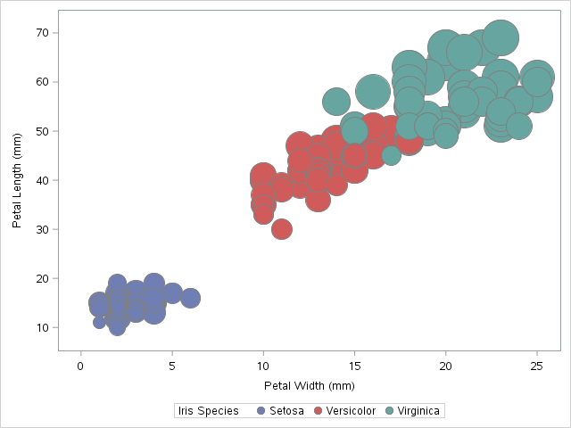

```sas
proc sgplot
    /* group - color by a categorical variable */
    /* lineattrs - sets the bubble outline color and other outline attributes */
    data=sashelp.iris;
    bubble x=petalwidth y=petallength size=sepallength /
        group=species
        lineattrs=(color=grey);
run;
```

##### Scatter plot with regression overlay using `PROC SGPLOT`

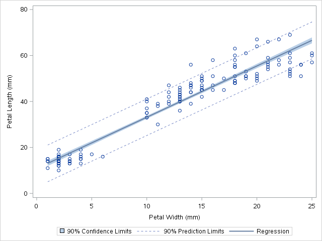

```sas
proc sgplot
    /* clm - confidence limits for mean predicted values */
    /* cli - prediction limits for individual predicted values */
    /* alpha - set threshold for clm and cli limits */
    data=sashelp.iris;
    reg x=petalwidth y=petallength /
    clm cli alpha=0.1;
run;
```

##### Stack bar chart with `PROC SGPLOT`

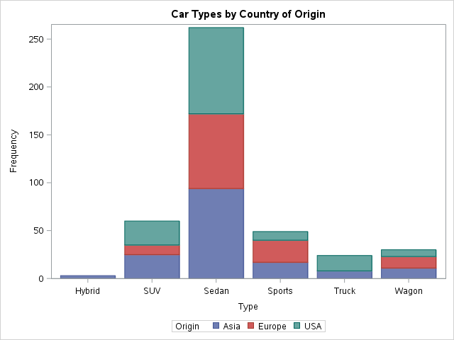

```sas
proc sgplot
    /* sashelp.cars is a sample data set */
    /* vbar variable on x-axis */
    /* group - splits vertical bars */
    /* add title */
    data=sashelp.cars;
    vbar type / group=origin;
    title 'Car Types by Country of Origin';
run;
```